# How Weather Shapes Our Moods & Action

## Weather Affects this much to our day?️

Let’s kick things off with a HOT CHOCOLATE MOOD!

[figure not shown]

In this story, I’ll walk you through how the weather impacts our **moods, clothing choices, and activities** based on the data I collected from a daily weather observation survey. By looking at temperature changes, mood patterns, and activity trends, we can get a clearer picture of how the weather affects us day to day.

## How Temperature Changes Throughout the Day?

Have a look at how temperature variation throughout the day…

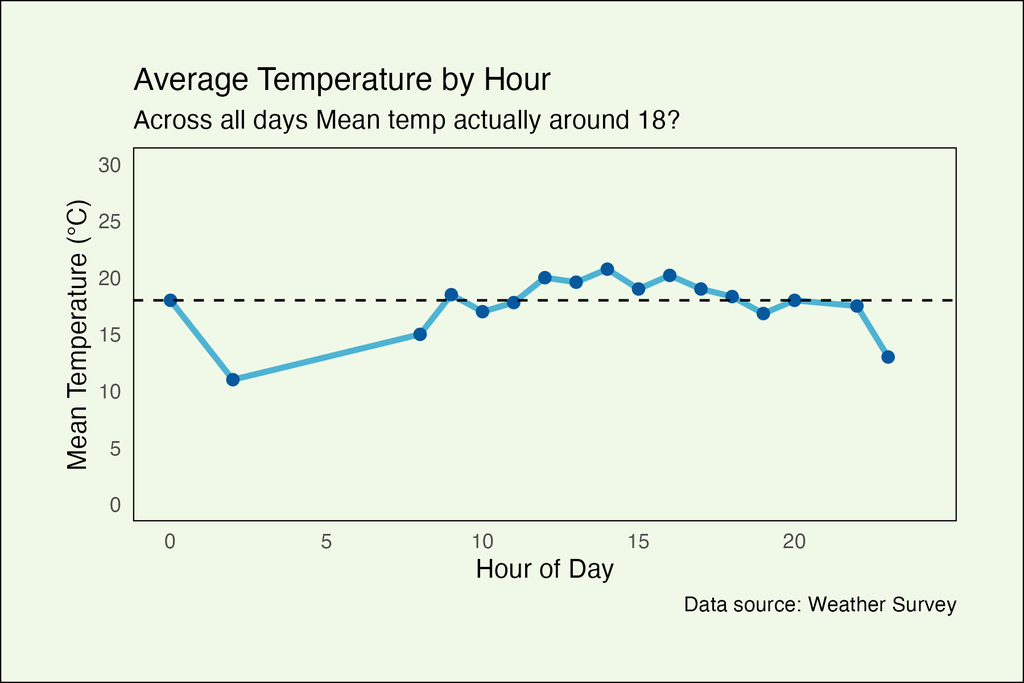

Line graph showing temperature variation throughout the day, with warmer temperatures at noon and cooler mornings/evenings

See? Yes! The average temperature across all days is actually around 18°C.

- The first graph shows how the **temperature changes hour by hour throughout the day**.
- What we can clearly see is that temperatures tend to be warmer in the middle of the day, while mornings and evenings are usually cooler.
- These shifts in temperature might influence what we do during the day, how we feel, and even what we choose to wear, depending on the time of day.

Hmm, it’s so interesting… But have you ever wondered if temperature shifts actually change what we wear, do, and feel?

I am sure you would love to know! Then keep reading my story…You will be surprised.

## How Activities Affect What We Wear?

Here, I took a closer look at how our mood and clothing choices change depending on what we’re doing.

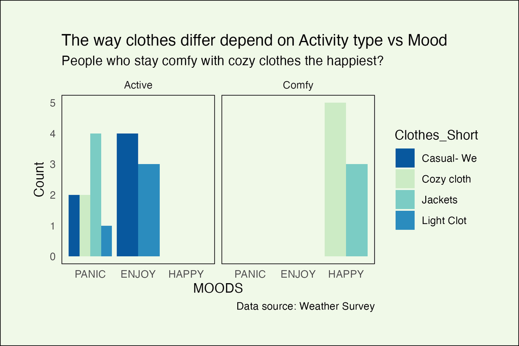

Bar graph illustrating clothing choices for different activities and moods, showing cozy clothes for relaxation and lighter clothes for active weather

- When people are engaged in *“comfy”* activities like relaxing, they tend to wear cozy, comfortable clothing.
- If you’re just chilling, you’ll probably throw on something soft and comfy. But what if you’re out and about? Well, the weather plays a big role in that choice.
- When it’s *warmer, people tend to feel more active*, so they wear lighter clothes or maybe some casual jeans for comfort.
- But what happens on those super cozy, rainy, or cloudy days (which definitely scream for **HOT CHOCOLATE!**)? We feel sleepy, relaxed, and often end up staying indoors to study or work.
  - We crave hot food, and of course, cozy clothes are a must! Think of a cold Christmas morning—comfy clothes all the way!

## Different Weather types affect Our mood??

Go ahead and have a look, You might be surprised by the findings!….

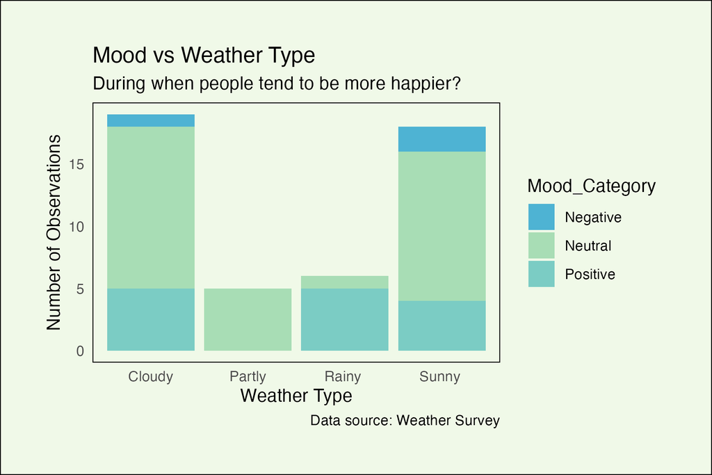

Did you see *how different weather conditions (cloudy, sunny, rainy) are linked to different mood states.* ?

This is so cool but wait, you have not reach to the most exciting part… HAHA!

## Let us Cut Shapes for FUN!!!

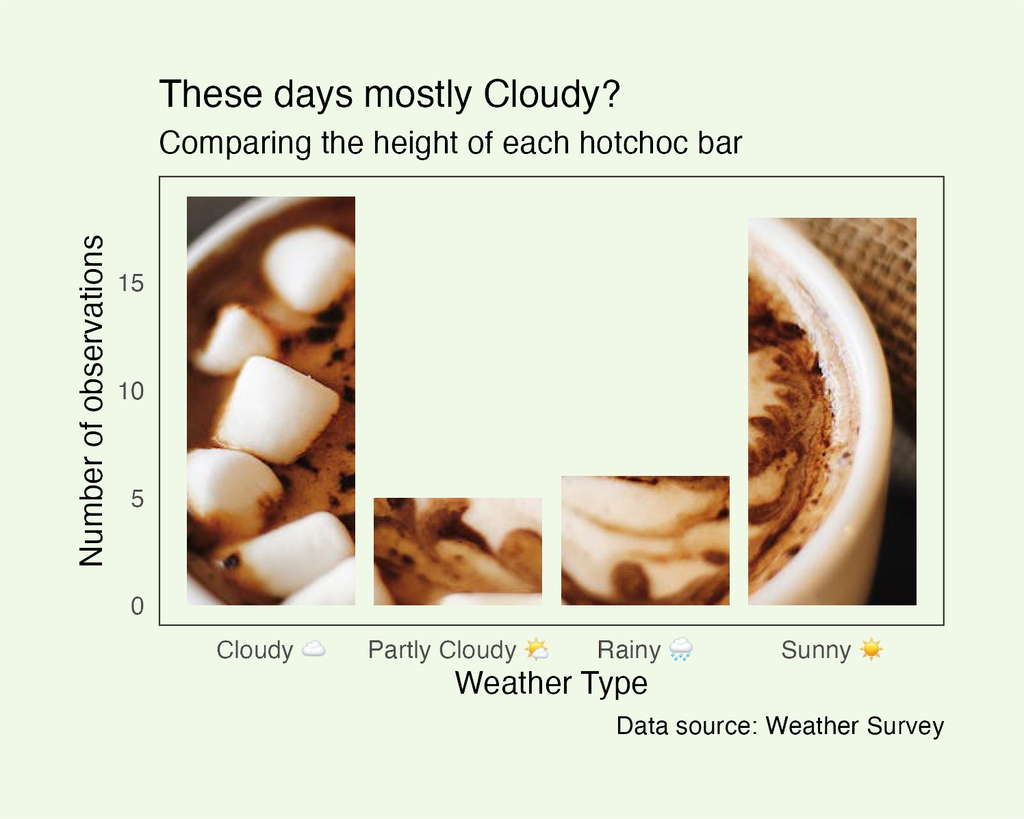

image of hot chocolate cup divided to visualize weather data, with cloudy weather being the most recorded

Am I surprising you way too much??? I know you enjoying these plots.

- To wrap it all up, I used a cutting image plot and cut the hot chocolate into the overall weather observation plot. It is so FUN right?

You can see I may have a bit of an obsession with hot chocolate! Haha!,

- I showed what was the most recorded weather type throughout these data collections dates using my hot chocolate cup.
- Guess what? You can see, by comparing the height of these cute hot chocolate bars **Cloudy** weather was the most common, and it makes sense as when it’s cloudy, people are probably staying indoors, cozying up, and enjoying a nice cup of hot chocolate.

## So what have we learned?

How much the weather shapes not only our mood but also our clothing choices and activities. Whether it’s the temperature or the mood on rainy days, *there’s no doubt that the weather plays a big role in how we feel and act.* Adding a bit of fun through memes and creative visuals helped tell this story in a way that goes beyond just the numbers.

So next time it’s cloudy or rainy, I’ll probably be craving hot chocolate and now I know that’s perfectly okay.